# Bike Share Analysis

##### The bike share company make most of their profit from annual memberships.

##### The marketing team wants to maximize annual membership by targeting casual riders.

##### Before making this decision, they want to make sure how casual riders and annual members

##### ride their bike differently by providing data insights and visualizations.

##### By cleaning and analyzing data, it can provide some insights to why casual riders

##### buy annual memberships.

```r
library(tidyverse)
library(lubridate)
library(ggplot2)
library(dplyr)
library(hms)
getwd()
```

```
[1] "/Users/yooneekim/Desktop"
```

#### tried glimpse function to see the data types for each column

```r
glimpse(nov_2020)
glimpse(dec_2020)
glimpse(jan_2021)
glimpse(feb_2021)
glimpse(mar_2021)
glimpse(apr_2021)
glimpse(may_2021)
glimpse(jun_2021)
glimpse(jul_2021)
glimpse(aug_2021)
glimpse(sep_2021)
glimpse(oct_2021)
```

##### binding all data sets together

```r
all_trips <- bind_rows(nov_2020,dec_2020,jan_2021,feb_2021,mar_2021,apr_2021,may_2021,jun_2021,jul_2021,aug_2021,sep_2021,oct_2021)
```

[output not shown]

##### I tried to get mean, max, and min for ride_length, but caculating won’t work in a time frame.

##### Instead, I converted from time to numeric and then used as.ITime function to get the time.

```r
all_trips$ride_length <- as.POSIXct(all_trips$ride_length,format="%H:%M:%S")
all_trips$ride_length <- as.numeric(all_trips$ride_length)
all_trips$ride_length
```

[output not shown]

[output cut: 42 more lines]

```r
library(data.table)
```

```r
mean(all_trips$ride_length,na.rm=TRUE)
```

```
[1] 1201.462
```

```r
data.table::as.ITime(1021.462)
```

```
[1] "00:17:01"
```

##### max time 23 hours 59 mins and 22 seconds

```r
max(all_trips$ride_length,na.rm = TRUE)
```

```
[1] 86362
```

```r
data.table::as.ITime(86362)
```

```
[1] "23:59:22"
```

##### min time was 0

```r
min(all_trips$ride_length, na.rm=TRUE)
```

```
[1] 0
```

```r
data.table::as.ITime(0)
```

```
[1] "00:00:00"
```

```r
summary(all_trips$ride_length)
```

```
   Min. 1st Qu.  Median    Mean 3rd Qu.    Max.    NA's
      0     418     742    1201    1344   86362    4218
```

#### comparing casual members and annual members

#### casual members average ride time was 27 minutes 27 seconds.Whereas members

#### members average ride time 13 mins and 43 secs.

```r
aggregate(all_trips$ride_length~all_trips$member_casual,FUN= mean)
```

| all_trips$member_casual | all_trips$ride_length |
| --- | --- |
| casual | 1647.0227 |
| member | 823.4027 |

```r
data.table::as.ITime(1647.0227)
```

```
[1] "00:27:27"
```

```r
data.table::as.ITime(823.4027)
```

```
[1] "00:13:43"
```

#### median ride_length was 16 mins and 20 seconds on casual members and 9 mins and 54secs

#### on members

```r
aggregate(all_trips$ride_length~all_trips$member_casual,FUN=median)
```

| all_trips$member_casual | all_trips$ride_length |
| --- | --- |
| casual | 980 |
| member | 594 |

```r
data.table::as.ITime(980)
```

```
[1] "00:16:20"
```

```r
data.table::as.ITime(594)
```

```
[1] "00:09:54"
```

#### casual members maximum ride length was about 23 hours 59 mins and 22seconds.Members

#### ride_length was 23 hours 53 mins and 44 seconds

```r
aggregate(all_trips$ride_length~all_trips$member_casual,FUN=max)
```

| all_trips$member_casual | all_trips$ride_length |
| --- | --- |
| casual | 86362 |
| member | 86024 |

```r
data.table::as.ITime(86362)
```

```
[1] "23:59:22"
```

```r
data.table::as.ITime(86024)
```

```
[1] "23:53:44"
```

#### The minimum ride_length from casual and members were 0 .

#### day_of_week is in numbers. I changed the numbers into days to make it easier understand.

```r
aggregate(all_trips$ride_length~all_trips$member_casual,FUN = min)
```

| all_trips$member_casual | all_trips$ride_length |
| --- | --- |
| casual | 0 |
| member | 0 |

#### converted numbers to days.

```r
all_trips <- all_trips %>%
  mutate(day_of_week = recode(day_of_week
                              ,"1"="Sunday"
                              ,"2"="Monday"
                              ,"3"="Tuesday"
                              ,"4"="Wednesday"
                              ,"5"= "Thursday"
                              ,"6"="Friday"
                              ,"7"= "Saturday"))
```

## Visualization

#### Counting Annual members and casual riders.

#### There are more number of annual members than casual riders.

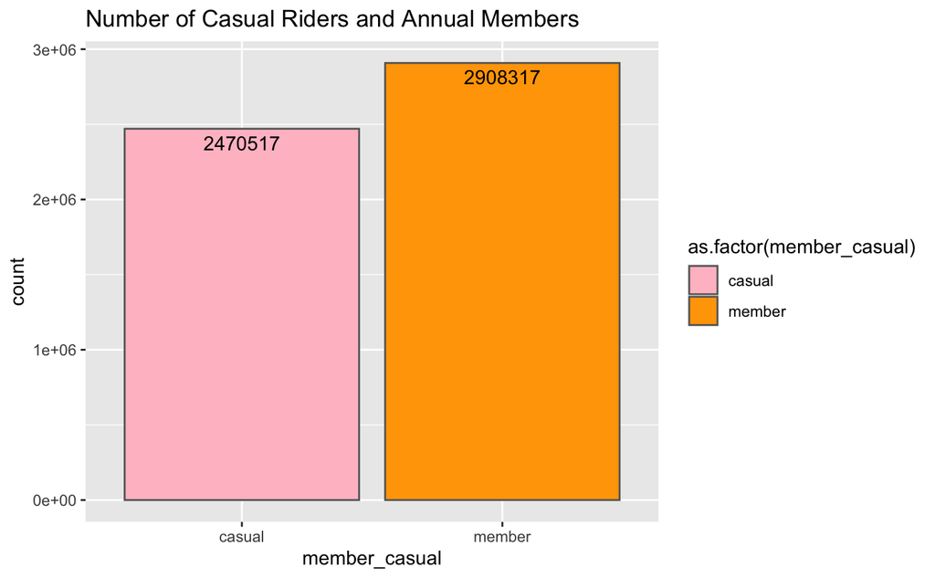

```r
ggplot(all_trips,aes(x=member_casual,fill=as.factor(member_casual)))+
  geom_bar(color="grey40")+
  geom_text(aes(label=..count..),stat="count",vjust=1.5)+
  scale_fill_manual(values=c("pink","orange"))+
  labs(title="Number of Casual Riders and Annual Members")
```

#### Number of Rides During the Week.

#### Annual members ride more often than casual riders during the weekdays. But, casual riders

#### ride more during the weekends.

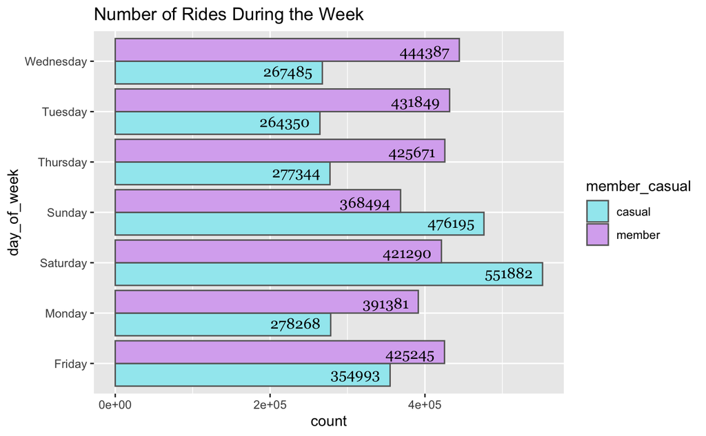

```r
all_trips %>%
  group_by(day_of_week,member_casual)%>%
  summarise(count=n()) %>%
  ggplot(aes(x=day_of_week,y=count, fill=member_casual,label=count)) +
  geom_bar(stat="identity",position="dodge",color="grey40") +
  scale_fill_manual(values=c("#a1e9f0","#d9b1f0"))+
  geom_text(aes(label=count),position=position_dodge(width= 0.8),hjust=1.2,family="Georgia") +
  labs(title="Number of Rides During the Week") +
  coord_flip()
```

#### Mean ride length for annual members and casual riders.

#### In this bar chart, casual riders ride longer than casual members.

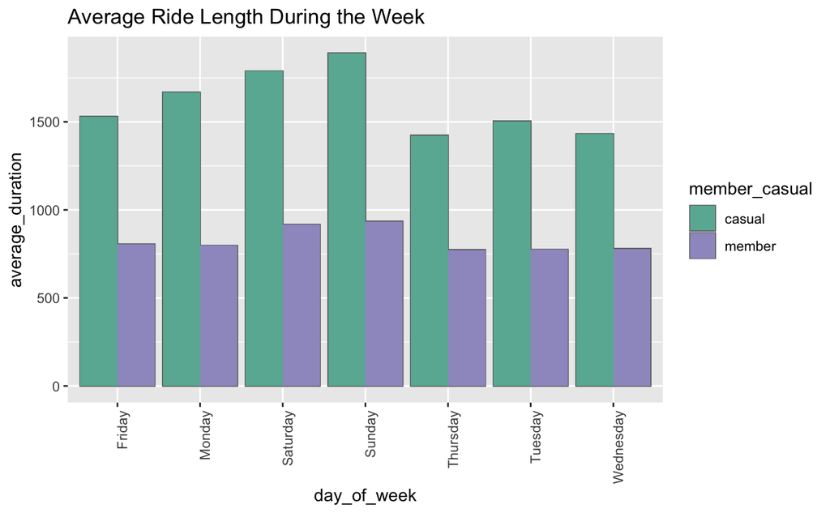

```r
all_trips %>%
  group_by(member_casual, day_of_week) %>%
  summarise(average_duration=mean(ride_length,na.rm=T)) %>%
  ggplot(aes(x=day_of_week,y=average_duration,fill=member_casual)) +
  geom_bar(stat="identity",position="dodge",color="grey40") +
  scale_fill_manual(values=c("#69b3a2","#9E9AC8"))+
  geom_col(position=position_dodge()) +
  labs(title="Average Ride Length During the Week")+
  theme(axis.text.x=element_text(angle=90,hjust=1))
```

#### Since the time is converted into numeric, maximum average ride length was 1890 by casual riders on sunday.

#### 1890 is about 31 mins and 40 sec. Whereas 1500 is about 25 mins and all the annual memebers seem to be

#### closest from 800 to 900 this ranges from 13 mins to 15 mins. (1000 is 16mins and 40sec)

```r
aggregate(all_trips$ride_length~all_trips$day_of_week+all_trips$member_casual,FUN=mean)
```

| all_trips$day_of_week | all_trips$member_casual | all_trips$ride_length |
| --- | --- | --- |
| Friday | casual | 1530.2302 |
| Monday | casual | 1667.5636 |
| Saturday | casual | 1787.4353 |
| Sunday | casual | 1890.2838 |
| Thursday | casual | 1423.1377 |
| Tuesday | casual | 1504.0579 |
| Wednesday | casual | 1431.5097 |
| Friday | member | 805.0941 |
| Monday | member | 796.8726 |
| Saturday | member | 916.2631 |

[output cut: 4 more lines]

```r
data.table::as.ITime(1900)
```

```
[1] "00:31:40"
```

```r
data.table::as.ITime(1500)
```

```
[1] "00:25:00"
```

```r
data.table::as.ITime(1000)
```

```
[1] "00:16:40"
```

```r
data.table::as.ITime(900)
```

```
[1] "00:15:00"
```

### Conclusion

#### As displayed on the graph, casual riders have higher average ride length compared to annual members,while

#### annual members tend to ride more during the week, but casual riders tend to ride more annual members on weekends.Hence, promotion during the weekends can help increase annual memberships.

[output not shown]